# ALY6040 M4 - Technique Practice - SVM

Instructor: Dr. Marcus Ellis

Student: Shahabaddin Feghahati

Completion Date: 03/19/2023

#### Introduction

The code provided is an example of using R programming language and the caret package to train a linear support vector machine (SVM) model for predicting the presence or absence of heart disease based on certain attributes. The data set used is from the Cleveland Clinic Foundation and the steps include loading and preprocessing the data, splitting it into training and testing datasets, training a linear SVM model with cross-validation and parameter tuning, making predictions on the testing data, and evaluating the model’s performance using a confusion matrix. The code also includes visualizations of the trained SVM model and its tuning parameters.

#### Importing the Heart Disease Dataset from UCI Machine Learning Repository into R

The UCI Machine Learning Repository is a source of various datasets for machine learning research. You can download and import the “heart” dataset from this repository by following these steps (UCI Machine Learning Repository: Heart Disease Data Set, n.d.):

Go to https://archive.ics.uci.edu/ml/index.php and search for the “heart disease” dataset. Download the “processed.cleveland.data” file from the dataset page. Save the downloaded file to your working directory or a folder of your choice. Import the file into R using the read.table() function.

#### Dataset Description: Variable Count, and Specific Variables of Interest

The ‘heart’ dataset contains medical information on 303 patients who underwent cardiac testing for potential heart disease. It has 14 variables, including age, sex, blood pressure, and diagnosis of heart disease, and is commonly used for developing and testing predictive models (Heart Diseases Prediction Using Spark 2.0.0, 2016).

The ‘heart’ dataset (processed.cleveland.data) contains the following columns:

1. V1: Age of the patient in years (numerical)
2. V2: Sex of the patient (binary: 0 = female, 1 = male)
3. V3: Chest pain type (ordinal: 1 = typical angina, 2 = atypical angina, 3 = non-anginal pain, 4 = asymptomatic)
4. V4: Resting blood pressure (numerical)
5. V5: Serum cholesterol in mg/dl (numerical)
6. V6: Fasting blood sugar > 120 mg/dl (binary: 0 = false, 1 = true)
7. V7: Resting electrocardiographic results (ordinal: 0 = normal, 1 = ST-T wave abnormality, 2 = left ventricular hypertrophy)
8. V8: Maximum heart rate achieved (numerical)
9. V9: Exercise-induced angina (binary: 0 = no, 1 = yes)
10. V10: ST depression induced by exercise relative to rest (numerical)
11. V11: Slope of the peak exercise ST segment (ordinal: 1 = upsloping, 2 = flat, 3 = downsloping)
12. V12: Number of major vessels colored by fluoroscopy (numerical)
13. V13: Thalassemia (ordinal: 3 = normal, 6 = fixed defect, 7 = reversible defect)
14. V14: Diagnosis of heart disease (0 = no disease, 1-2 = early stages, 3-4 = higher likelihood. Alternatively, it can be converted to binary format: 0 = no presence, 1 = presence)

#### Analysis

```r
# Load the necessary libraries and datasets

#Loading libraries
library('caret')

heart <- read.table("/Users/sf/Documents/Analytics/ALY6040 - Data Mining Applications MERGED - Winter 2023/ALY6040 R Project/processed.cleveland.data", header = FALSE, sep = ",", na.strings = "?")

# read the contents of the file into R as a character vector
#file_lines <- readLines("heart-disease.names")

# print the contents of the file
#cat(file_lines, sep = "\n")
```

```r
# Convert the 'heart' object to a string representation
str(heart)
```

```
## 'data.frame':    303 obs. of  14 variables:
##  $ V1 : num  63 67 67 37 41 56 62 57 63 53 ...
##  $ V2 : num  1 1 1 1 0 1 0 0 1 1 ...
##  $ V3 : num  1 4 4 3 2 2 4 4 4 4 ...
##  $ V4 : num  145 160 120 130 130 120 140 120 130 140 ...
##  $ V5 : num  233 286 229 250 204 236 268 354 254 203 ...
##  $ V6 : num  1 0 0 0 0 0 0 0 0 1 ...
##  $ V7 : num  2 2 2 0 2 0 2 0 2 2 ...
##  $ V8 : num  150 108 129 187 172 178 160 163 147 155 ...
##  $ V9 : num  0 1 1 0 0 0 0 1 0 1 ...
##  $ V10: num  2.3 1.5 2.6 3.5 1.4 0.8 3.6 0.6 1.4 3.1 ...
##  $ V11: num  3 2 2 3 1 1 3 1 2 3 ...
##  $ V12: num  0 3 2 0 0 0 2 0 1 0 ...
##  $ V13: num  6 3 7 3 3 3 3 3 7 7 ...
##  $ V14: int  0 2 1 0 0 0 3 0 2 1 ...
```

There are 303 observations and 14 variables. Variables V1 to V14 have different data types, including numeric and integer.

```r
# Remove rows with missing values
heart <- na.omit(heart)

# Convert values 2, 3, and 4 in column V14 to 1, for distinguishing presence (values 1-4) from absence (value 0) of heart disease
heart$V14 <- ifelse(heart$V14 %in% c(2, 3, 4), 1, heart$V14)
```

The code performs data preparation and cleaning operations on a data frame called “heart”. It removes missing values and creates a binary outcome variable for heart disease.

```r
# Display first few rows of the modified 'heart' object
head(heart)
```

```
##   V1 V2 V3  V4  V5 V6 V7  V8 V9 V10 V11 V12 V13 V14
## 1 63  1  1 145 233  1  2 150  0 2.3   3   0   6   0
## 2 67  1  4 160 286  0  2 108  1 1.5   2   3   3   1
## 3 67  1  4 120 229  0  2 129  1 2.6   2   2   7   1
## 4 37  1  3 130 250  0  0 187  0 3.5   3   0   3   0
## 5 41  0  2 130 204  0  2 172  0 1.4   1   0   3   0
## 6 56  1  2 120 236  0  0 178  0 0.8   1   0   3   0
```

The code “head(heart)” shows the first six rows of the ‘heart’ dataset, giving us a glimpse of the data and the values for the variables for the first few patients. It’s a quick way to get an idea of the structure and format of the data.

```r
# Create a training dataset and a testing dataset using the 'createDataPartition' function

set.seed(123) # set a seed for reproducibility
intrain <- createDataPartition(y = heart$V14, p= 0.7, list = FALSE)
training <- heart[intrain,]
testing <- heart[-intrain,]
```

The code creates a training dataset and a testing dataset by randomly selecting 70% of the rows from the ‘heart’ dataset as the training set using the ‘createDataPartition’ function and assigning the remaining 30% to the testing set. This is a common technique in machine learning to partition the dataset into training and testing sets for model development and evaluation.

```r
# Display the dimensions of the training and testing datasets
dim(training)
```

```
## [1] 208  14
```

```r
dim(testing)
```

```
## [1] 89 14
```

The ‘training’ dataset has 208 rows and 14 columns, while the ‘testing’ dataset has 89 rows and 14 columns.

```r
# Check if there are any missing values in the 'heart' object
anyNA(heart)
```

```
## [1] FALSE
```

The ‘anyNA(heart)’ function returns ‘FALSE’, indicating that the ‘heart’ object does not contain missing values.

```r
# Display summary statistics for the modified 'heart' object
summary(heart)
```

```
##        V1              V2               V3              V4
##  Min.   :29.00   Min.   :0.0000   Min.   :1.000   Min.   : 94.0
##  1st Qu.:48.00   1st Qu.:0.0000   1st Qu.:3.000   1st Qu.:120.0
##  Median :56.00   Median :1.0000   Median :3.000   Median :130.0
##  Mean   :54.54   Mean   :0.6768   Mean   :3.158   Mean   :131.7
##  3rd Qu.:61.00   3rd Qu.:1.0000   3rd Qu.:4.000   3rd Qu.:140.0
##  Max.   :77.00   Max.   :1.0000   Max.   :4.000   Max.   :200.0
##        V5              V6               V7               V8
##  Min.   :126.0   Min.   :0.0000   Min.   :0.0000   Min.   : 71.0
##  1st Qu.:211.0   1st Qu.:0.0000   1st Qu.:0.0000   1st Qu.:133.0
##  Median :243.0   Median :0.0000   Median :1.0000   Median :153.0
##  Mean   :247.4   Mean   :0.1448   Mean   :0.9966   Mean   :149.6
##  3rd Qu.:276.0   3rd Qu.:0.0000   3rd Qu.:2.0000   3rd Qu.:166.0
##  Max.   :564.0   Max.   :1.0000   Max.   :2.0000   Max.   :202.0
##        V9              V10             V11             V12
##  Min.   :0.0000   Min.   :0.000   Min.   :1.000   Min.   :0.0000
##  1st Qu.:0.0000   1st Qu.:0.000   1st Qu.:1.000   1st Qu.:0.0000
##  Median :0.0000   Median :0.800   Median :2.000   Median :0.0000
##  Mean   :0.3266   Mean   :1.056   Mean   :1.603   Mean   :0.6768
##  3rd Qu.:1.0000   3rd Qu.:1.600   3rd Qu.:2.000   3rd Qu.:1.0000
##  Max.   :1.0000   Max.   :6.200   Max.   :3.000   Max.   :3.0000
##       V13             V14
##  Min.   :3.000   Min.   :0.0000
##  1st Qu.:3.000   1st Qu.:0.0000
##  Median :3.000   Median :0.0000
##  Mean   :4.731   Mean   :0.4613
##  3rd Qu.:7.000   3rd Qu.:1.0000
##  Max.   :7.000   Max.   :1.0000
```

The data shows summary statistics (minimum, maximum, median, mean, quartiles) for 14 variables (V1 to V14) in the heart dataset. These variables relate to factors such as age, blood pressure, and cholesterol levels of patients with heart disease.

Some additional insights we can draw from the data are:

- The age of patients ranges from 29 to 77 years old (V1).
- Sex of patients is binary, where 0 represents female and 1 represents male (V2).
- Blood pressure ranges from 94 to 200 mm Hg (V4).
- Serum cholesterol level ranges from 126 to 564 mg/dl (V5).
- Resting electrocardiographic results are represented using integers 0, 1, and 2 (V7).
- Diagnosis of heart disease is binary, where 0 represents absence and 1 represents presence of heart disease (V14).

```r
# Convert the 'V14' column of the training dataset to a factor
training[["V14"]] = factor(training[["V14"]])

# Define a train control object for the 'train' function
trctrl <- trainControl(method = "repeatedcv", number = 10, repeats = 3)

# Train a linear support vector machine (SVM) model using the 'train' function
svm_Linear <- train(V14 ~., data = training, method = "svmLinear",
trControl=trctrl,
preProcess = c("center", "scale"),
tuneLength = 10)
```

The code trains a linear SVM model using the “train” function on a dataset called “training”. It converts the outcome variable to a factor and defines a train control object for cross-validation.

```r
# Display the trained SVM model object
svm_Linear
```

```
## Support Vector Machines with Linear Kernel
##
## 208 samples
##  13 predictor
##   2 classes: '0', '1'
##
## Pre-processing: centered (13), scaled (13)
## Resampling: Cross-Validated (10 fold, repeated 3 times)
## Summary of sample sizes: 188, 187, 188, 186, 186, 188, ...
## Resampling results:
##
##   Accuracy  Kappa
##   0.822684  0.6392332
##
## Tuning parameter 'C' was held constant at a value of 1
```

A Support Vector Machines (SVM) model with a linear kernel was used on a dataset containing 208 samples with 13 predictor variables and 2 classes labeled as ‘0’ and ‘1’. Pre-processing was done by centering and scaling the predictor variables. Cross-validation with 10 folds repeated 3 times was used to evaluate the model, and sample sizes were similar across folds. The model achieved an accuracy of 0.823 and a Kappa value of 0.639, indicating moderate agreement between predicted and actual classes. The tuning parameter ‘C’ was held constant at 1, which controls the trade-off between maximizing margin and minimizing classification error (Lecture 9: SVM, n.d.).

In SVM, C controls the balance between classification error and margin of separation. C=1 indicates equal importance given to both. Smaller C results in wider margin but more errors, while larger C leads to narrower margin but potential overfitting. Optimal C depends on the data and is determined via hyperparameter tuning (Lecture 9: SVM, n.d.).

The Kappa value is a measure of how reliable the model’s predictions are. A Kappa value of 1 means that the model’s predictions are perfectly reliable, while a Kappa value of 0 means that the model’s predictions are no better than random guessing. In this case, the Kappa value is 0.639, which means that the model’s predictions are somewhat reliable, but not perfect (Lecture 9: SVM, n.d.).

```r
# Use the trained SVM model to predict outcomes for the testing dataset
test_pred <- predict(svm_Linear, newdata = testing)
test_pred
```

```
##  [1] 1 1 0 0 0 0 0 0 0 1 1 0 0 0 0 1 0 1 1 1 0 1 0 1 1 1 0 0 0 1 0 1 1 1 0 0 0 0
## [39] 1 0 0 0 1 1 1 1 1 1 1 1 0 0 0 1 1 0 1 0 0 1 0 0 0 0 0 1 0 1 1 0 0 0 0 0 1 1
## [77] 0 0 1 1 0 1 1 1 0 0 1 1 1
## Levels: 0 1
```

The given data presents the predicted outcomes for the test dataset utilizing a tuned SVM model. The model provides binary predictions, where the outcomes are either 0 or 1.

```r
# Compute confusion matrix for the predicted outcomes and the actual outcomes of the testing dataset
confusionMatrix(table(test_pred, testing$V14))
```

```
## Confusion Matrix and Statistics
##
##
## test_pred  0  1
##         0 39  8
##         1  7 35
##
##                Accuracy : 0.8315
##                  95% CI : (0.7373, 0.9025)
##     No Information Rate : 0.5169
##     P-Value [Acc > NIR] : 5.422e-10
##
##                   Kappa : 0.6623
##
##  Mcnemar's Test P-Value : 1
##
##             Sensitivity : 0.8478
##             Specificity : 0.8140
##          Pos Pred Value : 0.8298
##          Neg Pred Value : 0.8333
##              Prevalence : 0.5169
##          Detection Rate : 0.4382
##    Detection Prevalence : 0.5281
##       Balanced Accuracy : 0.8309
##
##        'Positive' Class : 0
##
```

The SVM model made predictions on a test dataset, resulting in a confusion matrix that showed a high level of accuracy and substantial agreement with the actual classes. The model demonstrated good sensitivity and specificity in identifying positive and negative samples, with a positive predictive value of 82.98% and negative predictive value of 83.33%. Overall, the SVM model performed well in predicting the classes in the test dataset.

```r
# Define a grid of tuning parameters for the 'svmLinear' method
grid <- expand.grid(C = c(0.005, 0.01, 0.05, 0.1, 0.25, 0.5, 0.75, 1, 1.25, 1.5, 1.75, 2, 5))
```

The code defines a grid of tuning parameters for the ‘svmLinear’ method, where the ‘C’ parameter is varied over a range of values from 0.005 to 5.

```r
# Train an SVM model with tuning parameters using the 'train' function
svm_Linear_Grid <- train(V14 ~., data = training, method = "svmLinear",
trControl=trctrl,
preProcess = c("center", "scale"),
tuneGrid = grid,
tuneLength = 10)
```

This code trains an SVM model with tuning parameters using the ‘train’ function. The ‘svmLinear_Grid’ model is trained on the ‘training’ dataset, with the tuning parameters defined in the ‘grid’ object. The ‘trctrl’ object specifies the train control method and the number of repeats, while the ‘preProcess’ argument scales and centers the data before modeling.

```r
# Display the trained SVM model object with tuning parameters
svm_Linear_Grid
```

```
## Support Vector Machines with Linear Kernel
##
## 208 samples
##  13 predictor
##   2 classes: '0', '1'
##
## Pre-processing: centered (13), scaled (13)
## Resampling: Cross-Validated (10 fold, repeated 3 times)
## Summary of sample sizes: 188, 188, 187, 187, 186, 188, ...
## Resampling results across tuning parameters:
##
##   C      Accuracy   Kappa
##   0.005  0.8351732  0.6580559
##   0.010  0.8404040  0.6719914
##   0.050  0.8260245  0.6446396
##   0.100  0.8198846  0.6327505
##   0.250  0.8182900  0.6306704
##   0.500  0.8247186  0.6433346
##   0.750  0.8278932  0.6496988
##   1.000  0.8245599  0.6432401
##   1.250  0.8229726  0.6401012
##   1.500  0.8213059  0.6364858
##   1.750  0.8213059  0.6364858
##   2.000  0.8213059  0.6364858
##   5.000  0.8180519  0.6302113
##
## Accuracy was used to select the optimal model using the largest value.
## The final value used for the model was C = 0.01.
```

The SVM model was trained on a dataset with 208 samples and 13 predictors using a linear kernel. Cross-validation was used to evaluate the model performance, and the optimal model was selected based on the highest accuracy score with C set to 0.01. The model showed moderate to high accuracy and substantial agreement between predicted and actual classes, indicating that it performed well in predicting the classes of the dataset (Joseph, 2022).

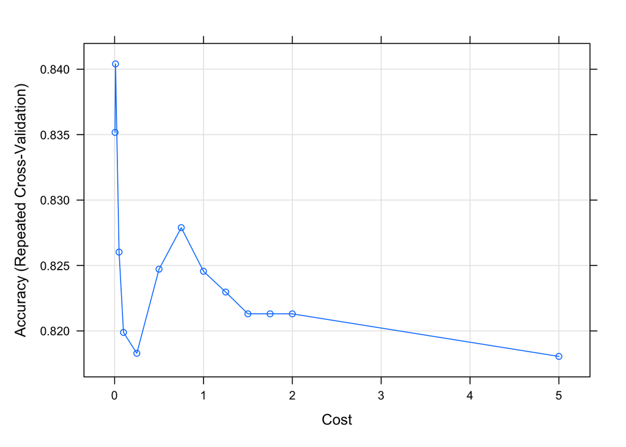

```r
# Display a plot of the tuned SVM model object
plot(svm_Linear_Grid)
```

The parameter C in SVM represents the penalty for misclassification. A smaller value of C allows for more misclassifications, leading to a wider margin, while a larger value of C penalizes misclassifications more heavily, leading to a narrower margin (Lecture 9: SVM, n.d.).

The plot above shows the accuracy of the SVM model for different values of C (cost). The accuracy of the model is highest for C=0.01, with an accuracy of 0.8404. The accuracy of the model is lowest when the value of C is 0.25 and 5.00, with an accuracy of 0.8183 and 0.8180.

However, SVM performance depends on data complexity, preprocessing, and hyperparameters. Cross-validation is crucial for accurate evaluation, and experimenting with different hyperparameters is necessary to find the best accuracy (Lecture 9: SVM, n.d.).

```r
# Use the tuned SVM model to predict outcomes for the testing dataset
test_pred_grid <- predict(svm_Linear_Grid, newdata = testing)
test_pred_grid
```

```
##  [1] 1 1 0 0 0 0 0 0 0 1 1 0 0 0 0 1 0 1 1 0 0 1 0 1 1 1 0 0 0 1 0 1 1 1 0 0 0 0
## [39] 1 0 0 0 1 1 1 1 1 1 0 1 0 0 0 1 1 0 1 0 0 1 0 0 0 0 0 1 0 0 1 0 0 0 0 0 1 1
## [77] 0 0 1 1 0 1 1 1 0 0 1 1 1
## Levels: 0 1
```

The data above is the predicted outcomes for the testing dataset using the tuned SVM model. The predicted outcomes are binary, with a value of 0 or 1.

```r
# Compute confusion matrix for the predicted outcomes and the actual outcomes of the testing dataset using the tuned SVM model
confusionMatrix(table(test_pred_grid, testing$V14))
```

```
## Confusion Matrix and Statistics
##
##
## test_pred_grid  0  1
##              0 41  9
##              1  5 34
##
##                Accuracy : 0.8427
##                  95% CI : (0.7502, 0.9112)
##     No Information Rate : 0.5169
##     P-Value [Acc > NIR] : 1.137e-10
##
##                   Kappa : 0.6841
##
##  Mcnemar's Test P-Value : 0.4227
##
##             Sensitivity : 0.8913
##             Specificity : 0.7907
##          Pos Pred Value : 0.8200
##          Neg Pred Value : 0.8718
##              Prevalence : 0.5169
##          Detection Rate : 0.4607
##    Detection Prevalence : 0.5618
##       Balanced Accuracy : 0.8410
##
##        'Positive' Class : 0
##
```

The SVM model has an accuracy of 0.8427, with a Kappa score of 0.6841. The model has high sensitivity (0.8913) but lower specificity (0.7907). The positive predictive value is 0.82 and the negative predictive value is 0.8718. Overall, the model performs well in detecting the positive class.

#### Conclusion

This code uses R and the caret package to build and evaluate a linear SVM model for predicting heart disease presence or absence. The data is preprocessed and cleaned, and the model is trained with cross-validation and parameter tuning. The model’s performance is evaluated using a confusion matrix, and there are visualizations of the trained model and its tuning parameters. This is a helpful example for building and evaluating ML models in R with caret.

To enhance the model’s performance trying other machine learning algorithms can be considered. Further evaluation can be done by calculating additional evaluation metrics such as F1 score, and ROC-AUC. Implementing these enhancements and evaluating the model’s performance can provide insights on further improvements that can be made.

#### References

*Heart Diseases Prediction using Spark 2.0.0.* (2016, October 18). Packt Hub. https://hub.packtpub.com/heart-diseases-prediction-using-spark-200/

Joseph. (2022, August 16). *What is Kappa in Machine Learning?* reason.town. https://reason.town/kappa-in-machine-learning/

Kabacoff, R. (2015). *R in action: data analysis and graphics with R* (Second edition.). Manning Publications.

*Lecture 9: SVM.* (n.d.). cs.cornell.edu. Retrieved March 18, 2023, from https://www.cs.cornell.edu/courses/cs4780/2018fa/lectures/lecturenote09.html

Run R code online. (n.d.). Retrieved March 2, 2023, from https://rdrr.io/snippets/

*UCI Machine Learning Repository: Heart Disease Data Set.* (n.d.). archive.ics.uci.edu. Retrieved March 17, 2023, from https://archive.ics.uci.edu/ml/datasets/Heart+Disease